# Some more simulations

Davide Risso

June 2, 2016

# Using simulated counts from clusterExperiment package

```r
knitr::opts_chunk$set(fig.align="center", cache=FALSE, error=FALSE, message=FALSE, echo=FALSE, warning=FALSE, results="markup", eval=TRUE)
```

The data consist of 300 cells with 153 genes, 51 of which are informative to define three groups, the others being noise. The expression levels are simulated from a Gaussian distribution with added Poisson noise.

There is no need for normalization in these data, so my intuition is that setting the parameters `size.fact` and `pi.fact` should have no effect.

## PCA

First, we will see how PCA is able to recover the three groups, with and without centering and with and without scaling.

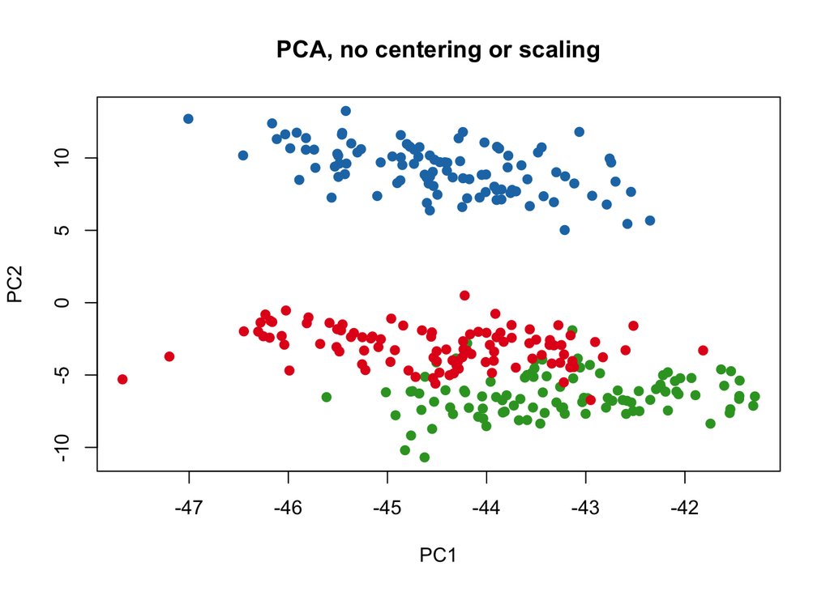

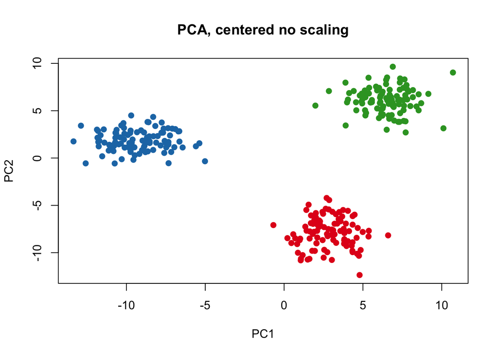

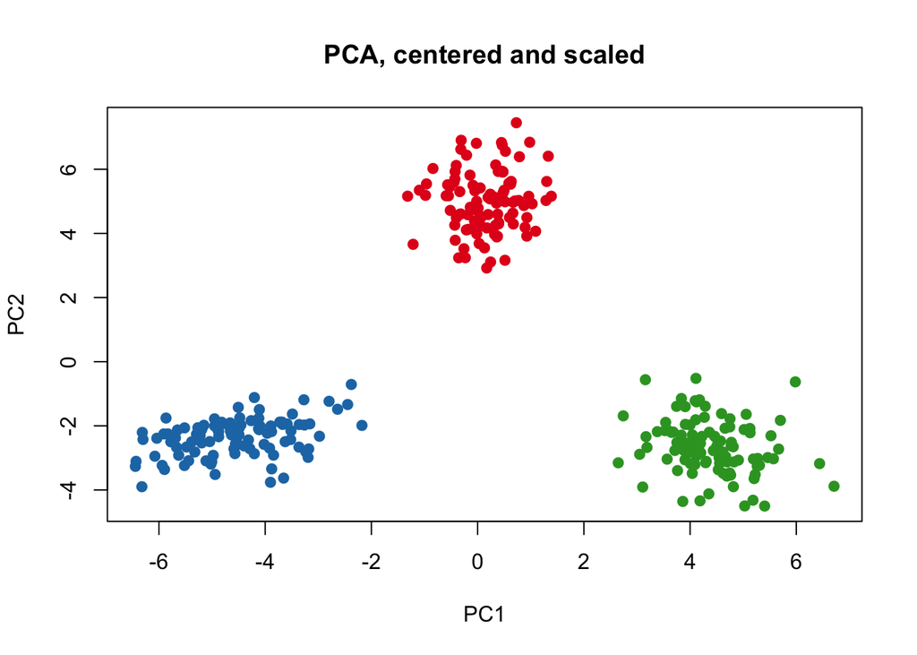

Centering has a big effect on PCA, scaling not so much.

## ZINB

We now run `zinb.PCA.full` with the default parameters, except that we vary the `center` parameter to see if it has a similar effect to that of PCA.

```
## Iteration 1
## log-likelihood = -272485.2
##    user  system elapsed
##   1.318   0.033   1.351
##    user  system elapsed
##   2.332   0.059   2.391
## Iteration 2
## log-likelihood = -243777.4
##    user  system elapsed
##   0.788   0.007   0.795
##    user  system elapsed
##   1.202   0.037   1.239
## Iteration 3
## log-likelihood = -243777.4
```

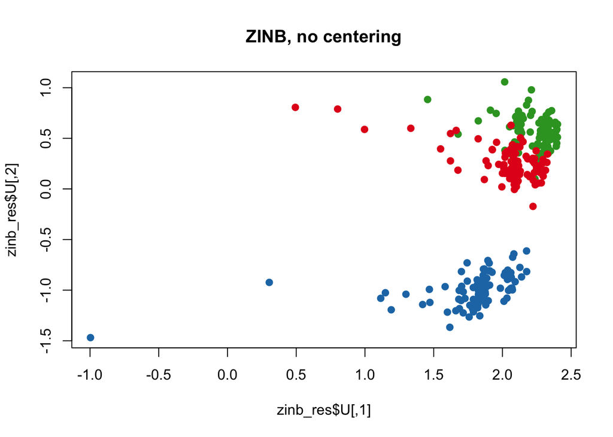

```
## Iteration 1
## log-likelihood = -3181468
##    user  system elapsed
##   3.979   0.079   4.058
##    user  system elapsed
##   1.225   0.060   1.285
## Iteration 2
## log-likelihood = -332695.7
##    user  system elapsed
##   1.148   0.020   1.167
##    user  system elapsed
##   1.162   0.029   1.191
## Iteration 3
## log-likelihood = -332693.3
```

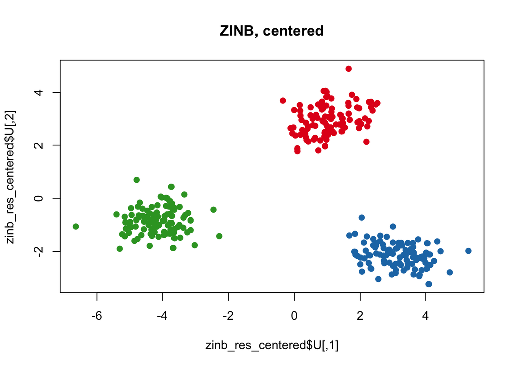

The ZINB PCA is behaving very similarly to PCA, i.e., the centering is essential to recover the three groups.

Now we can check the values of the size factors.

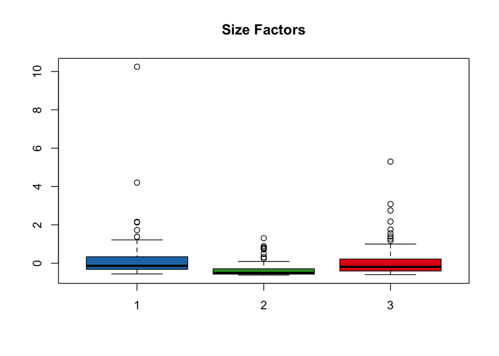

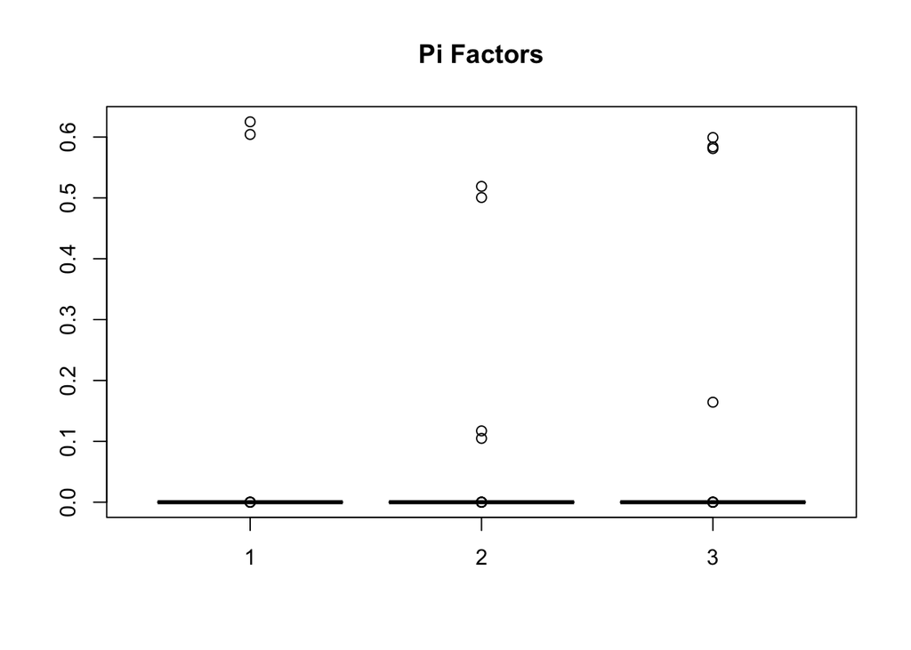

The size factors are capturing the difference between cluster 2 and the rest. However, the model seems robust to this, and U still captures that difference.

What happens if we do not include the size factors in the model?

```
## Iteration 1
## log-likelihood = -3055722
##    user  system elapsed
##   4.105   0.017   4.122
##    user  system elapsed
##   1.125   0.056   1.181
## Iteration 2
## log-likelihood = -323011.8
##    user  system elapsed
##   0.763   0.062   0.824
##    user  system elapsed
##   1.121   0.060   1.181
## Iteration 3
## log-likelihood = -323011.8
```

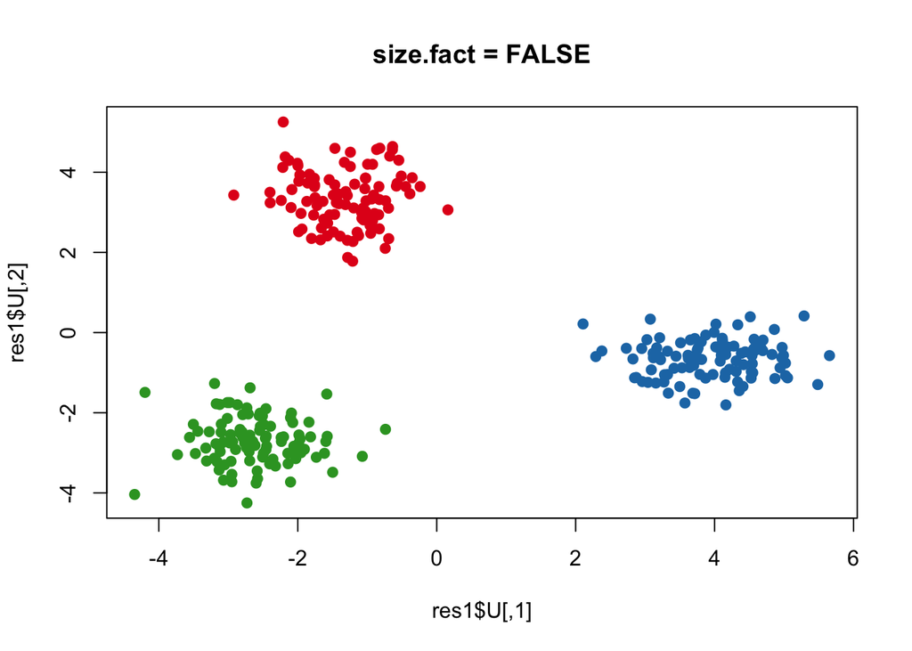

```
## Iteration 1
## log-likelihood = -3055722
##    user  system elapsed
##   4.223   0.157   4.379
##    user  system elapsed
##   1.057   0.030   1.086
## Iteration 2
## log-likelihood = -322904.3
##    user  system elapsed
##   1.273   0.004   1.277
##    user  system elapsed
##   1.027   0.025   1.053
## Iteration 3
## log-likelihood = -322903.9
```

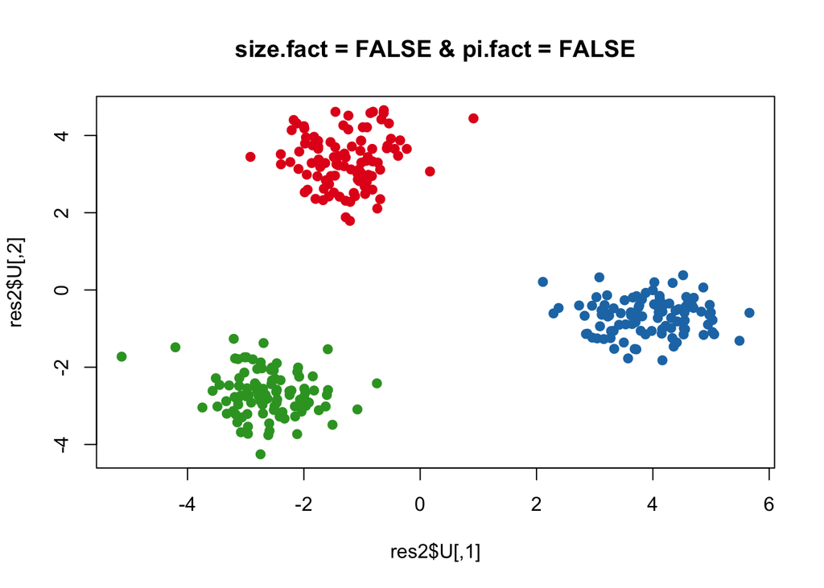